# CPLN 675 Midterm Project: Forecasting Flood Inundation

Huidi Hu

March 25, 2019

# 1 Motivation

The world is now exposed to more severe and prevalent flood risk than in the past decades. With climate change, the sea level is rising, and the weather is becoming more extreme. Such challenges demand an integrated flood risk management plan based on accurate and generalizable predictions, which requires a new method to predict flood risk in a timely and efficient manner. By establishing the flood inundation model, the government will be able to assign tax revenues and federal funds to the critical areas, as well as better coordinate regional flood infrastructures and future developments.

# 2 Data

First, load the requisite packages and create a mapTheme() function that is used to standardized the map outputs created below.

```r
library(tidyverse)
library(sf)
library(QuantPsyc)
library(RSocrata)
library(viridis)
library(caret)
library(spatstat)
library(spdep)
library(FNN)
library(grid)
library(gridExtra)
library(knitr)
library(kableExtra)
library(plotROC)
library(pROC)

mapTheme <- function(base_size = 12) {
  theme(
    text = element_text( color = "black"),
    plot.title = element_text(size = 14,colour = "black"),
    plot.subtitle=element_text(face="italic"),
    plot.caption=element_text(hjust=0),
    axis.ticks = element_blank(),
    panel.background = element_blank(),axis.title = element_blank(),
    axis.text = element_blank(),
    axis.title.x = element_blank(),
    axis.title.y = element_blank(),
    panel.grid.minor = element_blank(),
    panel.border = element_rect(colour = "black", fill=NA, size=2)
  )
}
```

Download data and create base maps, including city boundary, flood map and fishnet.

```r
limit <-
  st_read("./midTermProject_Data/CALGIS_CITYBOUND_LIMIT/CALGIS_CITYBOUND_LIMIT.shp") %>%
  st_transform(crs=3780)

fishnet <-
  st_make_grid(limit, cellsize = 500) %>%
  st_sf()

fishnet <-
  fishnet[limit,] %>%
  mutate(uniqueID = rownames(.)) %>%
  dplyr::select(uniqueID)

river <- st_read("./calgary/river_r.shp") %>%
  st_transform(crs=3780)

flood <- st_read("./calgary/flood_r.shp") %>%
  st_transform(crs=3780)
```

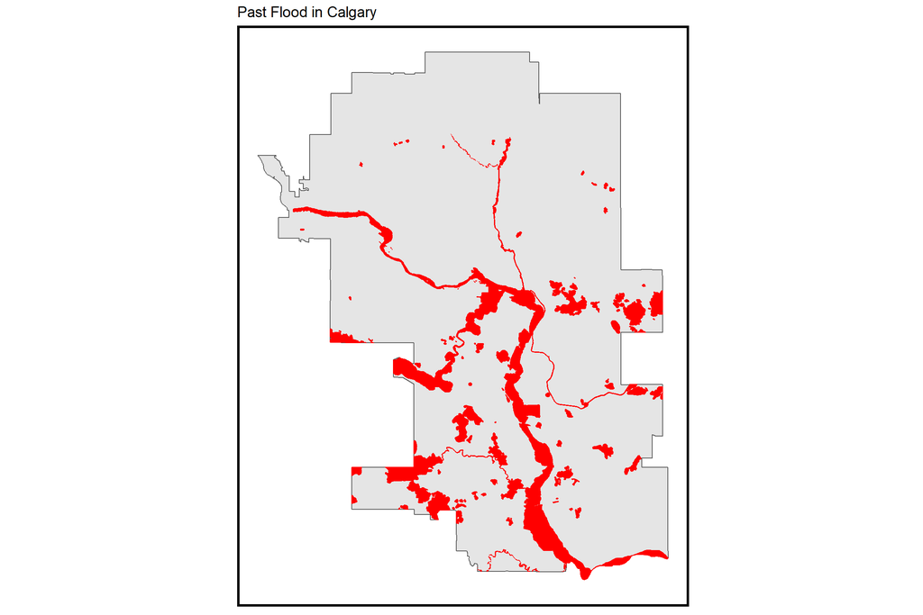

```r
ggplot() +
  geom_sf(data=limit) +
  geom_sf(data=flood,color="red", fill="red") +
  labs(title="Past Flood in Calgary") +
  mapTheme()
```

Next, we gather, wrangle and plot the flood risk factor data.

```r
library(raster)

landuse <- st_read("./calgary/landuse.shp") %>%
  st_transform(crs=3780)

elevation <- st_read("./calgary/elevation.shp") %>%
  st_transform(crs=3780)

drain <- st_read("./calgary/hydro/drainv.shp") %>%
  st_transform(crs=3780)

tree <-
  st_read("https://data.calgary.ca/resource/tfs4-3wwa.geojson") %>%
  st_transform(crs=3780)

sloper <- raster("./calgary/sloper.tif")

slopep <-
  rasterToPoints(sloper) %>%
  as.data.frame() %>%
  st_as_sf(coords = c("x", "y"), crs = 3780)

steepp <- slopep %>%
  filter(sloper > 3)

fac <- raster("./calgary/hydro/fac.tif")

facp <-
  rasterToPoints(fac) %>%
  as.data.frame() %>%
  st_as_sf(coords = c("x", "y"), crs = 3780)

band1 <- raster("./calgary/data/band1.tif")
band2 <- raster("./calgary/data/band2.tif")
band3 <- raster("./calgary/data/band3.tif")
band4 <- raster("./calgary/data/band4.tif")
band5 <- raster("./calgary/data/band5.tif")
band6 <- raster("./calgary/data/band6.tif")
band7 <- raster("./calgary/data/band7.tif")
band8 <- raster("./calgary/data/band8.tif")
band9 <- raster("./calgary/data/band9.tif")
band10 <- raster("./calgary/data/band10.tif")
band11 <- raster("./calgary/data/band11.tif")

band8 <- aggregate(band8, fact = 2)

image <- stack(band1, band2, band3, band4, band5, band6, band7,
               band8, band9, band10, band11)

ndvi <- (image[[5]] - image[[4]])/(image[[5]] + image[[4]])

ndvip <-
  rasterToPoints(ndvi) %>%
  as.data.frame() %>%
  st_as_sf(coords = c("x", "y"), crs = st_crs(ndvi))%>%
  st_transform(st_crs(limit))

greenp <- ndvip %>%
  filter(layer > 0.35) %>%
  st_transform(st_crs(limit))

streamp <- st_read("./calgary/hydro/streamp.shp")%>%
  st_transform(crs=3780)
```

We then join the flood map and the risk factors to the fishnet.

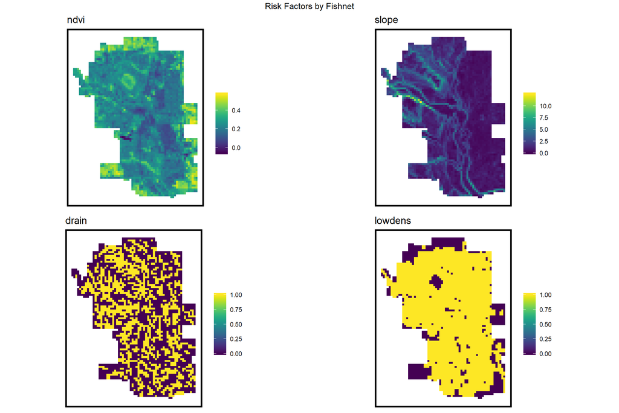

```r
#unique(landuse$major)

tbc_net <-
  landuse %>%
  filter(major== "Parks, Recreation and Public Education" | major== "Future Urban Development") %>%
  mutate(tbc =1) %>%
  aggregate(., fishnet, mean) %>%
  mutate(tbc = ifelse(is.na(tbc), 0, tbc))%>%
  dplyr::select(tbc)

lowdens_net <-
  landuse %>%
  filter(major== "Residential - Low Density"|major== "Residential - Medium Density"|major== "Industrial"|major== "Transportation and Utility Corridor"|major== "Major Infrastructure") %>%
  mutate(lowdens =1) %>%
  aggregate(., fishnet, mean) %>%
  mutate(lowdens = ifelse(is.na(lowdens), 0, lowdens))%>%
  dplyr::select(lowdens)

highdens_net <-
  landuse %>%
  filter(major== "Residential - High Density"|major== "Commercial - Core"|major== "Mixed Use"|major== "Institutional"|major== "Recreational"|major== "Commercial") %>%
  mutate(highdens =1) %>%
  aggregate(., fishnet, mean) %>%
  mutate(highdens = ifelse(is.na(highdens), 0, highdens))%>%
  dplyr::select(highdens)

elevation_net <-
  elevation %>%
  aggregate(., fishnet, mean)%>%
  mutate(GRIDCODE = ifelse(is.na(GRIDCODE), mean(na.omit(GRIDCODE)), GRIDCODE))
#plot(elevation_net)

slopep_net <-
  slopep %>%
  aggregate(., fishnet, mean)%>%
  mutate(sloper = ifelse(is.na(sloper), mean(na.omit(sloper)), sloper))
#plot(slopep_net)

steep_net <-
  steepp %>%
  mutate(steep =1) %>%
  aggregate(., fishnet, sum) %>%
  mutate(steep = ifelse(is.na(steep), 0, steep))%>%
  dplyr::select(steep)

tree_net<-
  tree %>%
  mutate(tree = 1) %>%
  dplyr::select(tree)%>%
  aggregate(., fishnet, sum) %>%
  mutate(tree = ifelse(is.na(tree), 0, tree))

drain_net<-
  drain %>%
  mutate(drain =1) %>%
  dplyr::select(drain)%>%
  aggregate(., fishnet, mean) %>%
  mutate(drain = ifelse(is.na(drain), 0, drain))

fac_net <-
  facp %>%
  aggregate(., fishnet, sum)

ndvi_net<-
  ndvip %>%
  aggregate(., fishnet, mean)%>%
  mutate(layer = ifelse(is.na(layer), mean(na.omit(layer)), layer))
#plot(ndvi_net)

green_net<-
  greenp %>%
  mutate(green =1) %>%
  aggregate(., fishnet, sum) %>%
  mutate(green = ifelse(is.na(green), 0, green))%>%
  dplyr::select(green)

vars_net <-
  cbind(tbc_net,lowdens_net, highdens_net, elevation_net, tree_net, drain_net, fac_net, slopep_net, steep_net, ndvi_net, green_net)%>%
  mutate(elevation=GRIDCODE,slope=sloper, ndvi=layer)%>%
  dplyr::select(tbc, lowdens, highdens, elevation, tree, drain, fac, slope, steep, ndvi, green)%>%
  mutate(uniqueID = rownames(.))

nn_function <- function(measureFrom,measureTo,k) {
  measureFrom_Matrix <-
    as.matrix(measureFrom)
  measureTo_Matrix <-
    as.matrix(measureTo)
  nn <-
    get.knnx(measureTo, measureFrom, k)$nn.dist
    output <-
      as.data.frame(nn) %>%
      rownames_to_column(var = "thisPoint") %>%
      gather(points, point_distance, V1:ncol(.)) %>%
      arrange(as.numeric(thisPoint)) %>%
      group_by(thisPoint) %>%
      summarize(pointDistance = mean(point_distance)) %>%
      arrange(as.numeric(thisPoint)) %>%
      dplyr::select(-thisPoint) %>%
      pull()

  return(output)
}

vars_net$steep.nn =
    nn_function(st_coordinates(st_centroid(vars_net)), st_coordinates(steepp), 3)

vars_net$green.nn =
    nn_function(st_coordinates(st_centroid(vars_net)), st_coordinates(greenp), 3)

vars_net$stream.nn =
    nn_function(st_coordinates(st_centroid(vars_net)), st_coordinates(streamp), 3)

vars_net2 <-
  vars_net %>%
  dplyr::select(ndvi,slope,drain,lowdens)

vars_net.long <-
  vars_net2 %>%
  gather(Variable, value, -geometry)

vars <- unique(vars_net.long$Variable)
mapList <- list()

for(i in vars){
  mapList[[i]] <-
    ggplot() +
    geom_sf(data = filter(vars_net.long, Variable == i), aes(fill=value), colour=NA) +
    scale_fill_viridis(name="") +
    labs(title=i) +
    mapTheme()}

do.call(grid.arrange,c(mapList, ncol =2, top = "Risk Factors by Fishnet"))
```

```r
river_net <-
  river %>%
  dplyr::select() %>%
  mutate(river = as.numeric(1)) %>%
  aggregate(., fishnet, mean) %>%
  mutate(river = ifelse(is.na(river), 0, river))

flood_net <-
  flood %>%
  dplyr::select() %>%
  mutate(flood = as.numeric(1)) %>%
  aggregate(., fishnet, mean) %>%
  mutate(flood = ifelse(is.na(flood), 0, flood))

final_net <-
  cbind(vars_net,flood_net)
```

# 3 Model

We start modeling by building another dataset of just the variables we want to analyze, as well as creating the training and test sets.

```r
#min(final_net$elevation)
#max(final_net$steep)
#max(final_net$green)

final <-
  final_net %>%
  mutate(elev = elevation-min(elevation)) %>%
  mutate(stee = steep/max(steep)) %>%
  mutate(gree = green/max(green)) %>%
  dplyr::select(-elevation, -steep,-green,-geometry.1)

final$tbc <- as.factor(final$tbc)
final$lowdens <- as.factor(final$lowdens)
final$highdens <- as.factor(final$highdens)

set.seed(3456)
trainIndex <- createDataPartition(y = paste(final$lowdens, final$tbc, final$highdens), p = .70,
                                  list = FALSE,
                                  times = 1)
finalTrain <- final[ trainIndex,]
finalTest  <- final[-trainIndex,]
```

Now let’s estimate a logistic regression model.

```r
finalModel <- glm(flood ~ .,
                    family="binomial"(link="logit"), data = finalTrain %>%
                                                            as.data.frame() %>%
                                                            dplyr::select(-geometry,-uniqueID))
summary(finalModel)
```

```
##
## Call:
## glm(formula = flood ~ ., family = binomial(link = "logit"), data = finalTrain %>%
##     as.data.frame() %>% dplyr::select(-geometry, -uniqueID))
##
## Deviance Residuals:
##      Min        1Q    Median        3Q       Max
## -2.25276  -0.62773  -0.30862  -0.05703   3.12503
##
## Coefficients:
##                   Estimate     Std. Error z value             Pr(>|z|)
## (Intercept)  3.10957314004  0.44415268135   7.001     0.00000000000254 ***
## tbc1         0.55912734600  0.20323694863   2.751              0.00594 **
## lowdens1    -0.97143956625  0.19577770224  -4.962     0.00000069788235 ***
## highdens1   -0.19559229040  0.13617657327  -1.436              0.15091
## tree         0.09563367812  0.05279868976   1.811              0.07010 .
## drain        0.10886677199  0.11695994208   0.931              0.35196
## fac          0.00000005070  0.00000001017   4.983     0.00000062490279 ***
## slope        0.16533788290  0.10025934101   1.649              0.09913 .
## ndvi        -6.19834127423  1.53635152098  -4.034     0.00005472914683 ***
## steep.nn    -0.00036079527  0.00012419961  -2.905              0.00367 **
## green.nn    -0.00159370720  0.00050833067  -3.135              0.00172 **
## stream.nn   -0.00098232882  0.00006885300 -14.267 < 0.0000000000000002 ***
## elev        -0.01395127743  0.00144636306  -9.646 < 0.0000000000000002 ***
## stee        -0.70335999732  0.65778490606  -1.069              0.28494
## gree         2.88480968562  0.54744825507   5.270     0.00000013675354 ***
## ---
## Signif. codes:  0 '***' 0.001 '**' 0.01 '*' 0.05 '.' 0.1 ' ' 1
##
## (Dispersion parameter for binomial family taken to be 1)
##
##     Null deviance: 2782.1  on 2506  degrees of freedom
## Residual deviance: 1933.0  on 2492  degrees of freedom
## AIC: 1963
##
## Number of Fisher Scoring iterations: 6
```

When it’s done, we output the predicted probability of a test set fishnet cell being flooded conditional on our model.

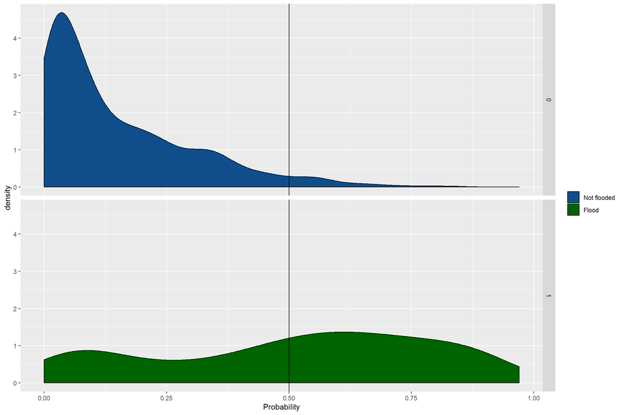

```r
classProbs <- predict(finalModel, finalTest, type="response")

testProbs <- data.frame(obs = as.numeric(finalTest$flood),
                        pred = classProbs)

ggplot(testProbs, aes(x = pred, fill=as.factor(obs))) + geom_density() +
  facet_grid(obs ~ .) + xlab("Probability") + geom_vline(xintercept = .5) +
  scale_fill_manual(values = c("dodgerblue4", "darkgreen"),
                      labels = c("Not flooded","Flood"),
                      name = "")
```

```r
testProbs$predClass  = ifelse(testProbs$pred > .5 ,1,0)

caret::confusionMatrix(reference = as.factor(testProbs$obs),
                       data = as.factor(testProbs$predClass),
                       positive = "1")
```

```
## Confusion Matrix and Statistics
##
##           Reference
## Prediction   0   1
##          0 769 114
##          1  31 154
##
##                Accuracy : 0.8642
##                  95% CI : (0.8422, 0.8842)
##     No Information Rate : 0.7491
##     P-Value [Acc > NIR] : < 0.00000000000000022
##
##                   Kappa : 0.5974
##
##  Mcnemar's Test P-Value : 0.000000000009778
##
##             Sensitivity : 0.5746
##             Specificity : 0.9613
##          Pos Pred Value : 0.8324
##          Neg Pred Value : 0.8709
##              Prevalence : 0.2509
##          Detection Rate : 0.1442
##    Detection Prevalence : 0.1732
##       Balanced Accuracy : 0.7679
##
##        'Positive' Class : 1
##
```

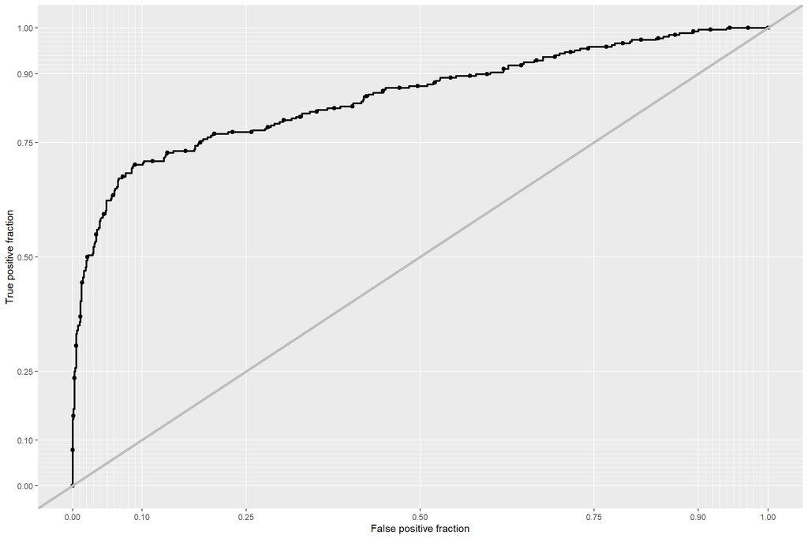

```r
ggplot(testProbs, aes(d = obs, m = pred)) +
  geom_roc(n.cuts = 50, labels = FALSE) +
  style_roc(theme = theme_grey) +
  geom_abline(slope = 1, intercept = 0, size = 1.5, color = 'grey')
```

```r
auc(testProbs$obs, testProbs$pred)
```

```
## Area under the curve: 0.85
```

We examine the goodness of fit metrics for random k-fold cross validation.

```r
ctrl <- trainControl(method = "cv",
                     number = 100,
                     savePredictions = TRUE)

cvFit <- train(as.factor(flood) ~ .,  data = finalTrain %>%
                                                as.data.frame() %>%
                                                dplyr::select(-geometry,-uniqueID),
               method="glm", family="binomial",
               trControl = ctrl)

cvFit
```

```
## Generalized Linear Model
##
## 2507 samples
##   14 predictor
##    2 classes: '0', '1'
##
## No pre-processing
## Resampling: Cross-Validated (100 fold)
## Summary of sample sizes: 2481, 2482, 2482, 2482, 2481, 2482, ...
## Resampling results:
##
##   Accuracy   Kappa
##   0.8469077  0.5296552
```

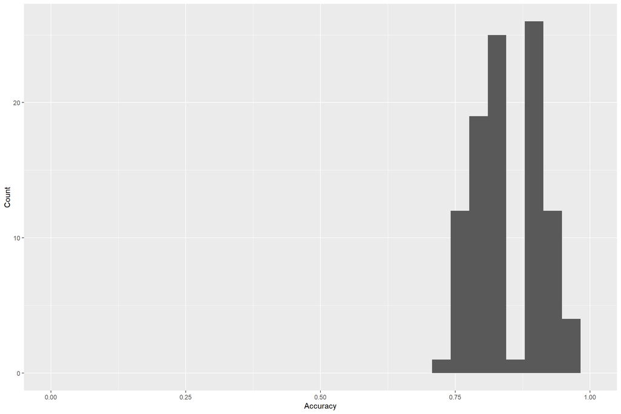

```r
ggplot(as.data.frame(cvFit$resample), aes(Accuracy)) +
  geom_histogram() +
  scale_x_continuous(limits = c(0, 1)) +
  labs(x="Accuracy",
       y="Count")
```

# 4 Map predictions

Now that we have tuned out model, let’s predict for the entire dataset.

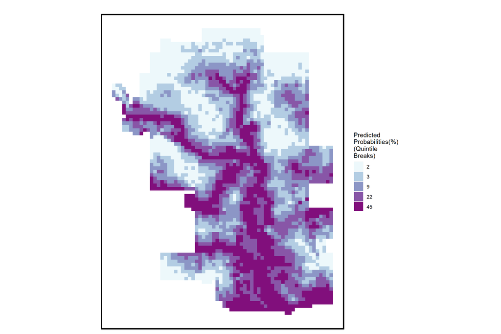

```r
allPredictions <-
  predict(cvFit, final, type="prob")[,2]

finalflood <-
  cbind(final,allPredictions) %>%
  mutate(allPredictions = round(allPredictions * 100))

ggplot() +
    geom_sf(data=finalflood, aes(fill=factor(ntile(allPredictions,5))), colour=NA) +
    scale_fill_manual(values = c("#edf8fb","#b3cde3","#8c96c6","#8856a7","#810f7c"),
                      labels=as.character(quantile(finalflood$allPredictions,
                                                 c(0.1,.2,.4,.6,.8),na.rm=T)),
                      name="Predicted\nProbabilities(%)\n(Quintile\nBreaks)") +
  mapTheme() +
  labs(title="")
```

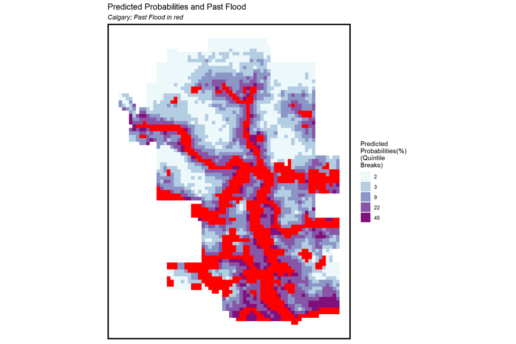

```r
ggplot() +
  geom_sf(data=finalflood, aes(fill=factor(ntile(allPredictions,5))), colour=NA) +
  scale_fill_manual(values = c("#edf8fb","#b3cde3","#8c96c6","#8856a7","#810f7c"),
                    labels=as.character(quantile(finalflood$allPredictions,
                                                 c(0.1,.2,.4,.6,.8),na.rm=T)),
                    name="Predicted\nProbabilities(%)\n(Quintile\nBreaks)") +
  geom_sf(data=finalflood %>%
               filter(flood == 1),
               fill="red",colour=NA) +
  mapTheme() +
  labs(title="Predicted Probabilities and Past Flood",
       subtitle="Calgary; Past Flood in red")
```

To further examine the spatial generalizability of our model, we plot the confusion matrix over space (for the train set).

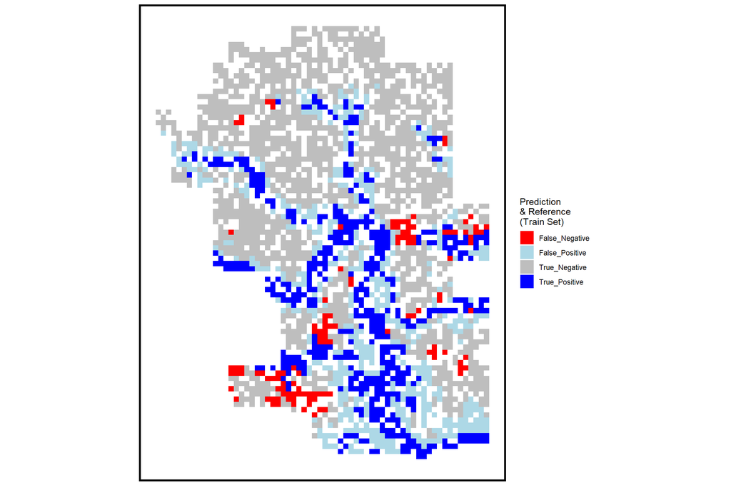

```r
trainPredictions <-
  predict(cvFit, finalTrain, type="prob")[,2]

matrix <-
  cbind(finalTrain,trainPredictions) %>%
  mutate(trainPredictions = round(trainPredictions * 100)) %>%
  mutate(pre = ifelse(trainPredictions>22,1,0)) %>%
  mutate(compare=
           ifelse(pre==0 & flood==0,"True_Negative",
           ifelse(pre==1 & flood==1,"True_Positive",
           ifelse(pre==0 & flood==1,"False_Negative",
           ifelse(pre==1 & flood==0,"False_Positive",0)))))

ggplot() +
    geom_sf(data=matrix, aes(fill=factor(compare)), colour=NA) +
    scale_fill_manual(values = c("red","lightblue","grey","blue"),
                      labels= c("False_Negative","False_Positive","True_Negative","True_Positive"),
                      name="Prediction\n& Reference\n(Train Set)") +
  mapTheme()
```

Lastly, we present the final inundation map for Calgary (entire dataset).

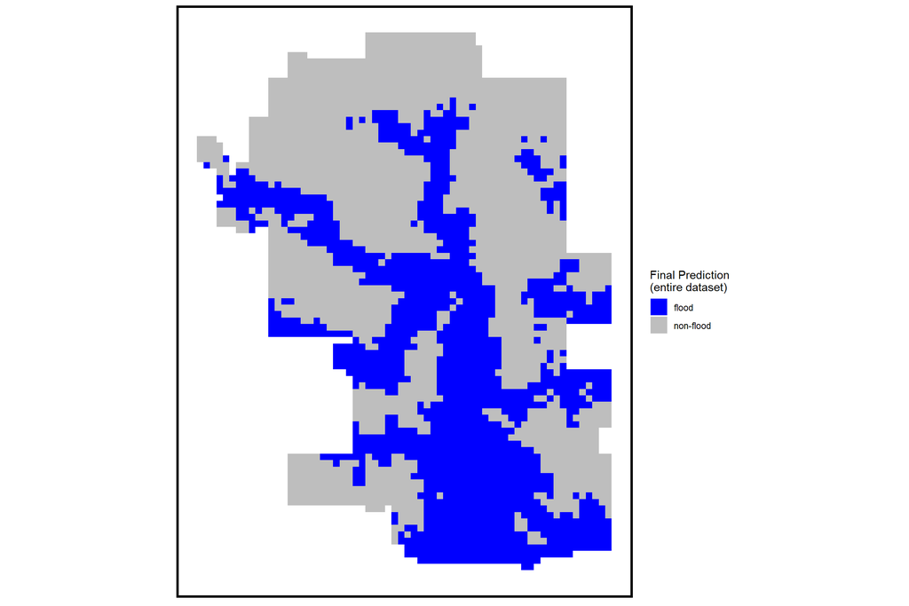

```r
finalpre <-
  finalflood %>%
  mutate(pre = ifelse(allPredictions<22,1,0))

ggplot() +
    geom_sf(data=finalpre, aes(fill=factor(pre)), colour=NA) +
    scale_fill_manual(values = c("blue","grey"),
                      labels=c("flood","non-flood"),
                      name="Final Prediction\n(entire dataset)") +
  mapTheme()
```

# 5 Comparable City: Denver

After training and validating our model on Calgary, we apply it on a comparable city: Denver.

```r
limit <-
  st_read("./denver/limit.shp") %>%
  st_transform(crs=6428)

fishnet <-
  st_make_grid(limit, cellsize = 500) %>%
  st_sf()

fishnet <-
  fishnet[limit,] %>%
  mutate(uniqueID = rownames(.)) %>%
  dplyr::select(uniqueID)

#plot(fishnet)
```

Next, we gather, wrangle and plot the flood risk factor data.

```r
#library(raster)
#plot(landuse)

landuse <- st_read("./denver/existing_landuse_2018/existing_landuse_2018.shp") %>%
  st_transform(crs=6428)

elevation <- st_read("./denver/elevation.shp") %>%
  st_transform(crs=6428)

drain <- st_read("./denver/hydro/drainv.shp") %>%
  st_transform(crs=6428)

tree <-
  st_read("./denver/tree_inventory/tree_inventory.shp") %>%
  st_transform(crs=6428)

sloper <- raster("./denver/sloper.tif")

slopep <-
  rasterToPoints(sloper) %>%
  as.data.frame() %>%
  st_as_sf(coords = c("x", "y"), crs = crs(sloper))%>%
  st_transform(st_crs(limit))

steepp <- slopep %>%
  filter(sloper > 3)

fac <- raster("./denver/hydro/fac.tif")

facp <-
  rasterToPoints(fac) %>%
  as.data.frame() %>%
  st_as_sf(coords = c("x", "y"), crs = st_crs(fac))%>%
  st_transform(st_crs(limit))


band4 <- raster("./denver/data/band4.tif")
band5 <- raster("./denver/data/band5.tif")

image <- stack(band4, band5)

ndvi <- (image[[2]] - image[[1]])/(image[[2]] + image[[1]])
#plot(ndvi)

ndvip <-
  rasterToPoints(ndvi) %>%
  as.data.frame() %>%
  st_as_sf(coords = c("x", "y"), crs = st_crs(ndvi))%>%
  st_transform(st_crs(limit))

greenp <- ndvip %>%
  filter(layer > 0.35) %>%
  st_transform(st_crs(limit))

streamp <- ndvip %>%
  filter(layer < 0.01) %>%
  st_transform(st_crs(limit))
```

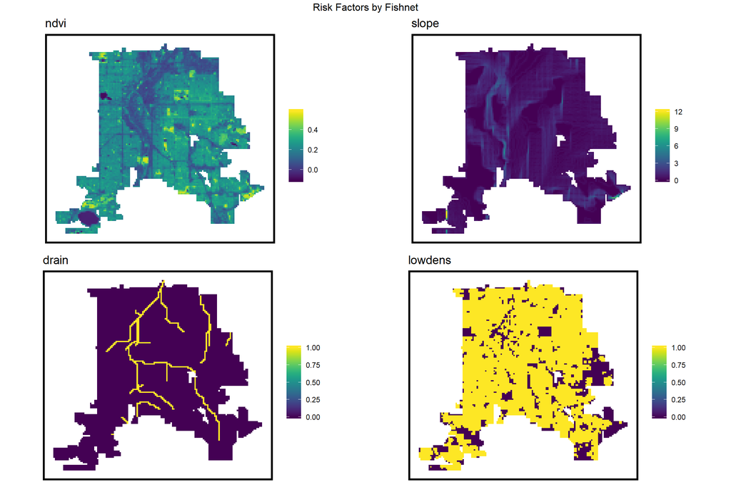

```r
#unique(landuse$CPD_LANDUS)

tbc_net <-
  landuse %>%
  filter(CPD_LANDUS== "Vacant" | CPD_LANDUS== "Agriculture"| CPD_LANDUS== "Park/Open Space") %>%
  mutate(tbc =1) %>%
  aggregate(., fishnet, mean) %>%
  mutate(tbc = ifelse(is.na(tbc), 0, tbc))%>%
  dplyr::select(tbc)

lowdens_net <-
  landuse %>%
  filter(CPD_LANDUS== "Single-unit Residential"|CPD_LANDUS== "Two-unit Residential"|CPD_LANDUS== "Industrial"|CPD_LANDUS== "Trans/Comm/Utilities"|CPD_LANDUS== "ROW/Road"|CPD_LANDUS== "Parking") %>%
  mutate(lowdens =1) %>%
  aggregate(., fishnet, mean) %>%
  mutate(lowdens = ifelse(is.na(lowdens), 0, lowdens))%>%
  dplyr::select(lowdens)

highdens_net <-
  landuse %>%
  filter(CPD_LANDUS== "Multi-unit Residential"|CPD_LANDUS== "Office"|CPD_LANDUS== "Mixed-use"|CPD_LANDUS== "Entertainment/Cultural"|CPD_LANDUS== "Commercial/Retail") %>%
  mutate(highdens =1) %>%
  aggregate(., fishnet, mean) %>%
  mutate(highdens = ifelse(is.na(highdens), 0, highdens))%>%
  dplyr::select(highdens)

elevation_net <-
  elevation %>%
  aggregate(., fishnet, mean)%>%
  mutate(GRIDCODE = ifelse(is.na(GRIDCODE), mean(na.omit(GRIDCODE)), GRIDCODE))
#plot(elevation_net)

slopep_net <-
  slopep %>%
  aggregate(., fishnet, mean)%>%
  mutate(sloper = ifelse(is.na(sloper), mean(na.omit(sloper)), sloper))
#plot(slopep_net)

steep_net <-
  steepp %>%
  mutate(steep =1) %>%
  aggregate(., fishnet, sum) %>%
  mutate(steep = ifelse(is.na(steep), 0, steep))%>%
  dplyr::select(steep)

tree_net<-
  tree %>%
  mutate(tree = 1) %>%
  dplyr::select(tree)%>%
  aggregate(., fishnet, sum) %>%
  mutate(tree = ifelse(is.na(tree), 0, tree))

drain_net<-
  drain %>%
  mutate(drain =1) %>%
  dplyr::select(drain)%>%
  aggregate(., fishnet, mean) %>%
  mutate(drain = ifelse(is.na(drain), 0, drain))

fac_net <-
  facp %>%
  aggregate(., fishnet, sum)

ndvi_net<-
  ndvip %>%
  aggregate(., fishnet, mean)%>%
  mutate(layer = ifelse(is.na(layer), mean(na.omit(layer)), layer))
#plot(ndvi_net)

green_net<-
  greenp %>%
  mutate(green =1) %>%
  aggregate(., fishnet, sum) %>%
  mutate(green = ifelse(is.na(green), 0, green))%>%
  dplyr::select(green)

vars_net <-
  cbind(tbc_net,lowdens_net, highdens_net, elevation_net, tree_net, drain_net, fac_net, slopep_net, steep_net, ndvi_net, green_net)%>%
  mutate(elevation=GRIDCODE,slope=sloper, ndvi=layer)%>%
  dplyr::select(tbc, lowdens, highdens, elevation, tree, drain, fac, slope, steep, ndvi, green)%>%
  mutate(uniqueID = rownames(.))

nn_function <- function(measureFrom,measureTo,k) {
  measureFrom_Matrix <-
    as.matrix(measureFrom)
  measureTo_Matrix <-
    as.matrix(measureTo)
  nn <-
    get.knnx(measureTo, measureFrom, k)$nn.dist
    output <-
      as.data.frame(nn) %>%
      rownames_to_column(var = "thisPoint") %>%
      gather(points, point_distance, V1:ncol(.)) %>%
      arrange(as.numeric(thisPoint)) %>%
      group_by(thisPoint) %>%
      summarize(pointDistance = mean(point_distance)) %>%
      arrange(as.numeric(thisPoint)) %>%
      dplyr::select(-thisPoint) %>%
      pull()

  return(output)
}

vars_net$steep.nn =
    nn_function(st_coordinates(st_centroid(vars_net)), st_coordinates(steepp), 3)

vars_net$green.nn =
    nn_function(st_coordinates(st_centroid(vars_net)), st_coordinates(greenp), 3)

vars_net$stream.nn =
    nn_function(st_coordinates(st_centroid(vars_net)), st_coordinates(streamp), 3)

vars_net2 <-
  vars_net %>%
  dplyr::select(ndvi,slope,drain,lowdens)

vars_net.long <-
  vars_net2 %>%
  gather(Variable, value, -geometry)

vars <- unique(vars_net.long$Variable)
mapList <- list()

for(i in vars){
  mapList[[i]] <-
    ggplot() +
    geom_sf(data = filter(vars_net.long, Variable == i), aes(fill=value), colour=NA) +
    scale_fill_viridis(name="") +
    labs(title=i) +
    mapTheme()}

do.call(grid.arrange,c(mapList, ncol =2, top = "Risk Factors by Fishnet"))
```

Lastly, we present the final inundation map for Denver (entire dataset).

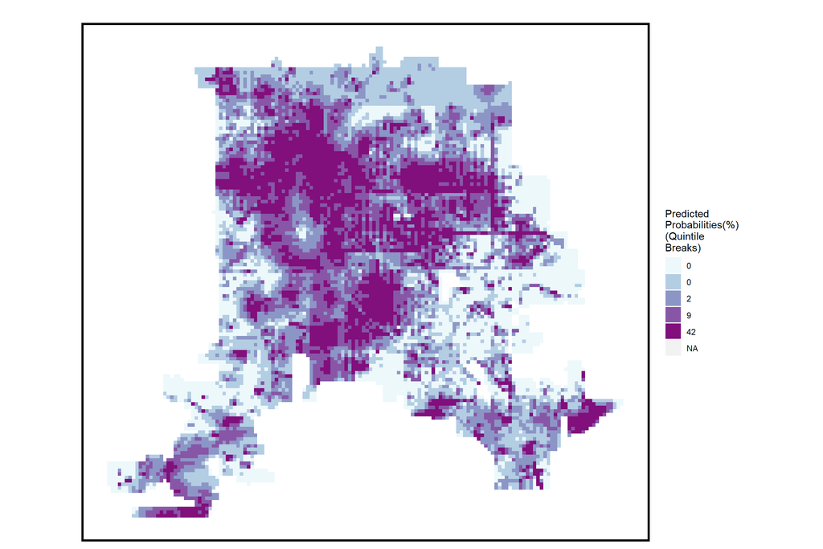

```r
#min(final_net$elevation)
#max(final_net$steep)
#max(final_net$green)

final2 <-
  vars_net %>%
  mutate(elev = elevation-min(elevation)) %>%
  mutate(stee = steep/max(steep)) %>%
  mutate(gree = green/max(green)) %>%
  dplyr::select(-elevation, -steep,-green)

final2$tbc <- as.factor(final2$tbc)
final2$lowdens <- as.factor(final2$lowdens)
final2$highdens <- as.factor(final2$highdens)

classProbs2 <- predict(finalModel, final2, type="response")

#typeof(classProbs2)

finalflood2 <-
  cbind(final2,classProbs2) %>%
  mutate(allPredictions2 = round(classProbs2 * 100))

ggplot() +
    geom_sf(data=finalflood2, aes(fill=factor(ntile(allPredictions2,5))), colour=NA) +
    scale_fill_manual(values = c("#edf8fb","#b3cde3","#8c96c6","#8856a7","#810f7c"),
                      labels=as.character(quantile(finalflood2$allPredictions2,
                                                 c(0.1,.2,.4,.6,.8),na.rm=T)),
                      name="Predicted\nProbabilities(%)\n(Quintile\nBreaks)") +
  mapTheme() +
  labs(title="")
```

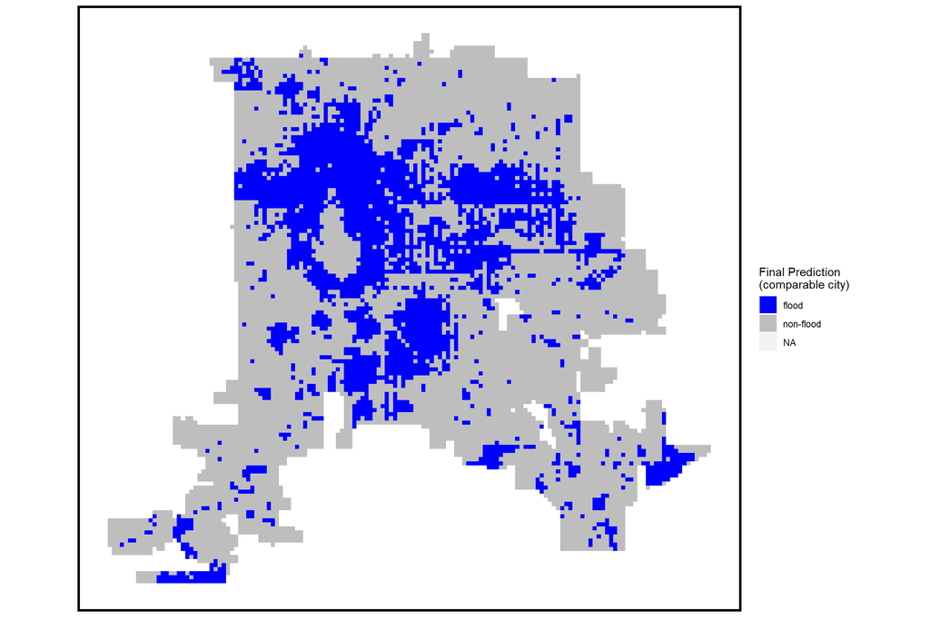

```r
finalpre2 <-
  finalflood2 %>%
  mutate(pre = ifelse(allPredictions2<22,1,0))

ggplot() +
    geom_sf(data=finalpre2, aes(fill=factor(pre)), colour=NA) +
    scale_fill_manual(values = c("blue","grey"),
                      labels=c("flood","non-flood"),
                      name="Final Prediction\n(comparable city)") +
  mapTheme()
```